# Negotiation: Strategy and Planning

Session 1

Luis F. Gómez L.

luis.gomezl@unimilitar.edu.co

Distance Learning Faculty

8 September, 2026

# Please Read Me

- Check the message **Welcome greeting** published in the News Bulletin Board.
- Dear student please edit your profile uploading a photo where your face is clearly visible.
- The purpose of the virtual meetings is to answer questions and not to make a summary of the study material.
- This presentation is based on (Lewicki et al., 2024, Chapter 4)
- **Purpose**
  - Understand and explore the primary elements of negotiation strategy, the decision-making process involved in choosing an approach, and the common stages through which negotiations evolve in order to plan effectively.

# The importance of planning in negotiations

- Some quotes about planning:

> “Everyone has a plan until they get punched in the mouth”

> “No battle plan ever survives contact with the enemy”
- Therefore, there is no need to plan?
  - Absolutely not, but if your plan is not flexible you will get punched in the mouth and no part of your plan will survive when you negotiate with the counterpart.
  - Also don”t expect everything will work millimetrically according to the plan because the counterpart might also have a plan and they will react strategically to your plan.
- Without planning results occur more by chance than by negotiator effort
  - Behaviour of Successful Negotiators: Find some successful negotiators and watch them during actual negotiations to find how they do it.
    - (Rackham & Carlisle, 1978a): planning is the foundation for any successful negotiation
    - (Rackham & Carlisle, 1978b): exploration of options, common ground, long-term implications, setting limits[^1] and use an issue planning method over sequence planning[^2]
- Also check out in the **Links of interest** the video: How to negotiate properly? (*¿Cómo Negociar Bien?*, 2018)

# Key steps in the planning process

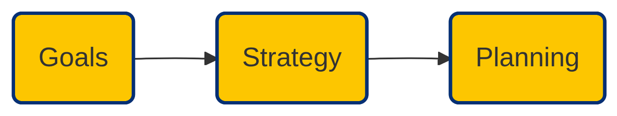

Figure 1: Relationship between key steps in the planning process (Lewicki et al., 2024, Chapter 4, p. 105)

# Goals

- The first step to execute a negotiation strategy is to determine one’s goals.
  - **Substantive**: goals about tangible factors (price, terms of a contract, product specifications)
  - **Intangible**: goals about intangible factors (personal values and emotions of the parties such as defeating the other party or reaching a conciliation at any cost)
  - **Procedural**: goals about how the negotiation process occurs (define plans or just have a voice during the negotiation)
- The negotiator must identify what kind of goals to pursue[^3]. What definitely cannot be ignored is the substantive goals given that it refers to the tangible aspects.
- When defining goals take into account these 4 aspects (Lewicki et al., 2024, Chapter 4, p 105-106):
  - Goals are specific objectives that are sought realistically.
  - Own goals can potentially be linked to the goals of the other parties.[^4]
  - If in identifying the goals these are not attainable then:
    - Modify them so that they are attainable
    - Discard the negotiation as an option to reach an agreement[^5]
  - The goals that are identified must be concrete, specific and measurable so that it is easier to:
    - Communicate to the other party what you want to achieve
    - Understand what the other parties want
    - Determine if the proposed proposals satisfy what you want to achieve

# Strategies

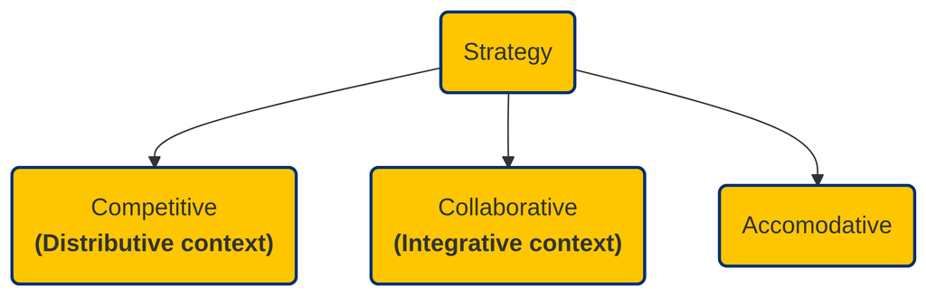

Figure 2: Different engagement strategies in a negotiation context (Lewicki et al., 2024, Chapter 4, p. 110)

# Phases of negotiation

- Before exploring the specific planning processes for negotiation, it is important to understand the typical phases in a negotiation
  - 7 key steps to an ideal negotiation process (Greenhalgh, 2001, p. 164):
    - Preparation
    - Relationship building
    - Information gathering
    - Information using
    - Bidding
    - Closing the deal
    - Implementing the agreement

# Planning process

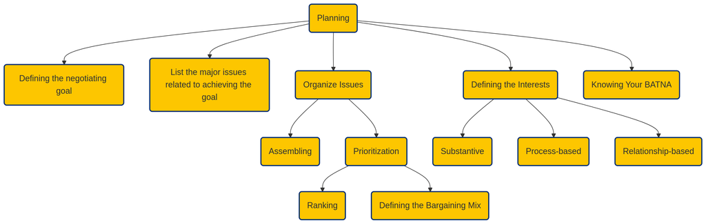

Figure 3: Key steps in the planning process (Lewicki et al., 2024, Chapter 4, pp. 114-128)

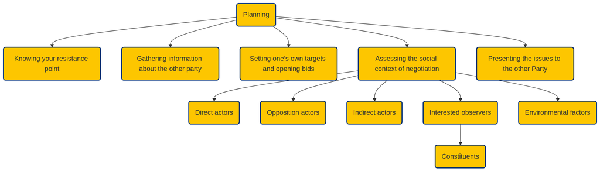

Figure 4: Key steps in the planning process (Lewicki et al., 2024, Chapter 4, pp. 114-128)

# Acknowledgments

- To my family that supports me
- To the taxpayers of Colombia and the [**UMNG students**](https://www.umng.edu.co/estudiante) who pay my salary
- To the [**Business Science**](https://www.business-science.io/) and [**R4DS Online Learning**](https://www.rfordatasci.com/) communities where I learn [**R**](https://www.r-project.org/about.html) and [**$\pi$-thon**](https://www.python.org/about/)
- To the [**R Core Team**](https://www.r-project.org/contributors.html), the creators of [**RStudio IDE**](https://rstudio.com/products/rstudio/), [**Quarto**](https://quarto.org/) and the authors and maintainers of the packages [**tufte**](https://CRAN.R-project.org/package=tufte) and [**tinytex**](https://CRAN.R-project.org/package=tinytex) for allowing me to access these tools without paying for a license

# References

*¿Cómo negociar bien?* (2018). https://youtu.be/CnF26cfIfQM

Greenhalgh, L. (2001). *Managing strategic relationships: The key to business success*. Free Press.

Lewicki, R. J., Barry, B., & Saunders, D. M. (2024). *Negociación* (9th ed.). McGraw-Hill Education. https://www-ebooks7-24-com.ezproxy.umng.edu.co/?il=40562

Rackham, N., & Carlisle, J. (1978a). The Effective Negotiator — Part 2: Planning for Negotiations. *Journal of European Industrial Training*, *2*(7), 2–5. https://doi.org/10.1108/eb002302

Rackham, N., & Carlisle, J. (1978b). The Effective Negotiator — Part I: The Behaviour of Successful Negotiators. *Journal of European Industrial Training*, *2*(6), 6–11. https://doi.org/10.1108/eb002297

## Footnotes

[^1]: Plan in terms of a range and not around a fixed point
[^2]: Issues are independent and not linked by a sequence
[^3]: Identifying goals in practical terms simply means making a list to prioritize them
[^4]: It is easier to reach an agreement if you have common goals
[^5]: Remember that negotiation as a form of **decision making** is not the only method that exists!